# exercise_machinelearning

Katie Evans

1/9/2018

# Summary

In this report, I am analyzing a dataset found [here](http://web.archive.org/web/20161224072740/http:/groupware.les.inf.puc-rio.br/har) on identifying how correct someone performs a weight lifting exercise using wearable sensors. I used a model that was able to predict with ~96% accuracy which activity was being performed.

# Tidy the data

```r
#first check for variables with near zero variation, probably not interesting
#also remove X, username, timestamps, and windows because this is not important to the model
Nsv <- nearZeroVar(training, saveMetrics = TRUE)
Nsv$activity <- rownames(Nsv)
Nsvs <- Nsv %>%
    filter(nzv == TRUE)
newtrain <- training %>%
    dplyr::select(-c(X, user_name, raw_timestamp_part_1, raw_timestamp_part_2, cvtd_timestamp, new_window, num_window),
                  -one_of(Nsvs$activity))

#Adjust for NA values by removing variables that are mostly NA, not going to be helpful
nas <- as.data.frame(sapply(newtrain, function(y) sum(is.na(y))/nrow(newtrain)))
colnames(nas) <- "perc"
nas$activity <- rownames(nas)
nas <- nas %>%
    dplyr::filter(perc < 0.5)
newertrain <- newtrain %>%
    dplyr::select(one_of(nas$activity))

#convert int to numeric
newertrain[,-53] <- sapply(newertrain[,-53], as.numeric)
```

# Explore the data

After the data tidying steps above, I am left with a cleaned dataset of 52 predictor variables for the outcome classe. This is still quite a few variables, but our algorithms can determine which ones are most important. Let’s plot a few to get an idea of which variables might be important to help us predict classe. Some variables look like they don’t change, but others like roll_dumbbell and roll_forearm could be useful. Let’s build a model with all of these predictors first.

```r
#look at the variables that can be used as predictors
names(newertrain)
```

```
##  [1] "roll_belt"            "pitch_belt"           "yaw_belt"
##  [4] "total_accel_belt"     "gyros_belt_x"         "gyros_belt_y"
##  [7] "gyros_belt_z"         "accel_belt_x"         "accel_belt_y"
## [10] "accel_belt_z"         "magnet_belt_x"        "magnet_belt_y"
## [13] "magnet_belt_z"        "roll_arm"             "pitch_arm"
## [16] "yaw_arm"              "total_accel_arm"      "gyros_arm_x"
## [19] "gyros_arm_y"          "gyros_arm_z"          "accel_arm_x"
## [22] "accel_arm_y"          "accel_arm_z"          "magnet_arm_x"
## [25] "magnet_arm_y"         "magnet_arm_z"         "roll_dumbbell"
## [28] "pitch_dumbbell"       "yaw_dumbbell"         "total_accel_dumbbell"
## [31] "gyros_dumbbell_x"     "gyros_dumbbell_y"     "gyros_dumbbell_z"
## [34] "accel_dumbbell_x"     "accel_dumbbell_y"     "accel_dumbbell_z"
## [37] "magnet_dumbbell_x"    "magnet_dumbbell_y"    "magnet_dumbbell_z"
## [40] "roll_forearm"         "pitch_forearm"        "yaw_forearm"
## [43] "total_accel_forearm"  "gyros_forearm_x"      "gyros_forearm_y"
## [46] "gyros_forearm_z"      "accel_forearm_x"      "accel_forearm_y"
## [49] "accel_forearm_z"      "magnet_forearm_x"     "magnet_forearm_y"
## [52] "magnet_forearm_z"     "classe"
```

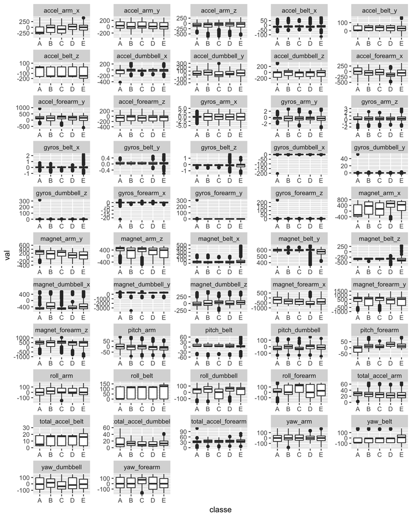

```r
#plot predictors by classe
plotdf <- newertrain %>%
    tidyr::gather(-classe, key = var, value = val)
ggplot(data = plotdf, aes(x = classe, y = val)) +
    geom_boxplot()+
    facet_wrap(~ var, nrow = 11, ncol = 5, scales = "free")
```

# Model prediction

Lets try a few basic models and see what the accuracy is like. I wanted to try PCA because we have so many variables and I figured they might be related to each other and we could instead find main principal components that best explained the data, however the accuracy is only about 50% and it cannot very well distinguish between the five classes.

```r
#Try PCA because there are still so many variables
#cannot use method = glm for categorical variables with more than 2 classes!
pca_model <- train(classe ~ ., method = "multinom", preProc = "pca", data = newertrain)
```

```r
confusionMatrix(cv$classe, predict(pca_model, cv))
```

```
## Confusion Matrix and Statistics
##
##           Reference
## Prediction    A    B    C    D    E
##          A 1504  172  195  306   55
##          B  348  595  223  174  178
##          C  378  156  658  119   57
##          D  149  117  149  750  121
##          E  138  256  149  180  719
##
## Overall Statistics
##
##                Accuracy : 0.5386
##                  95% CI : (0.5275, 0.5497)
##     No Information Rate : 0.3208
##     P-Value [Acc > NIR] : < 2.2e-16
##
##                   Kappa : 0.4144
##  Mcnemar's Test P-Value : < 2.2e-16
##
## Statistics by Class:
##
##                      Class: A Class: B Class: C Class: D Class: E
## Sensitivity            0.5975  0.45910  0.47889  0.49052  0.63628
## Specificity            0.8634  0.85908  0.89030  0.91515  0.89235
## Pos Pred Value         0.6738  0.39196  0.48099  0.58320  0.49861
## Neg Pred Value         0.8196  0.88922  0.88947  0.88125  0.93582
## Prevalence             0.3208  0.16518  0.17512  0.19488  0.14402
## Detection Rate         0.1917  0.07583  0.08386  0.09559  0.09164
## Detection Prevalence   0.2845  0.19347  0.17436  0.16391  0.18379
## Balanced Accuracy      0.7305  0.65909  0.68460  0.70283  0.76431
```

```r
#pca is surprisingly not very good. accuracy is only 50% and cannot really distinguish classes
```

I next thought I would try the tree model. This model also does not work very well, in fact it failed completely at finding classe D. Although it is very good at identifying class E! Below is the confusion matrix as well as a plot of the tree

```r
#try rpart
model_tree <- train(classe ~ ., method = "rpart", data = newertrain)
```

```r
model_tree$finalModel
```

```
## n= 11776
##
## node), split, n, loss, yval, (yprob)
##       * denotes terminal node
##
##  1) root 11776 8428 A (0.28 0.19 0.17 0.16 0.18)
##    2) roll_belt< 130.5 10792 7454 A (0.31 0.21 0.19 0.18 0.11)
##      4) pitch_forearm< -33.95 932    4 A (1 0.0043 0 0 0) *
##      5) pitch_forearm>=-33.95 9860 7450 A (0.24 0.23 0.21 0.2 0.12)
##       10) magnet_dumbbell_y< 437.5 8303 5946 A (0.28 0.18 0.24 0.19 0.11)
##         20) roll_forearm< 123.5 5199 3085 A (0.41 0.19 0.18 0.17 0.062) *
##         21) roll_forearm>=123.5 3104 2061 C (0.078 0.17 0.34 0.23 0.18) *
##       11) magnet_dumbbell_y>=437.5 1557  778 B (0.034 0.5 0.046 0.22 0.2) *
##    3) roll_belt>=130.5 984   10 E (0.01 0 0 0 0.99) *
```

```r
confusionMatrix(cv$classe, predict(model_tree, cv))
```

```
## Confusion Matrix and Statistics
##
##           Reference
## Prediction    A    B    C    D    E
##          A 2032   37  159    0    4
##          B  603  517  398    0    0
##          C  646   38  684    0    0
##          D  584  229  473    0    0
##          E  201  188  396    0  657
##
## Overall Statistics
##
##                Accuracy : 0.4958
##                  95% CI : (0.4847, 0.5069)
##     No Information Rate : 0.5182
##     P-Value [Acc > NIR] : 1
##
##                   Kappa : 0.3412
##  Mcnemar's Test P-Value : NA
##
## Statistics by Class:
##
##                      Class: A Class: B Class: C Class: D Class: E
## Sensitivity            0.4998  0.51239  0.32417       NA  0.99395
## Specificity            0.9471  0.85359  0.88075   0.8361  0.89074
## Pos Pred Value         0.9104  0.34058  0.50000       NA  0.45562
## Neg Pred Value         0.6377  0.92225  0.77987       NA  0.99938
## Prevalence             0.5182  0.12860  0.26893   0.0000  0.08425
## Detection Rate         0.2590  0.06589  0.08718   0.0000  0.08374
## Detection Prevalence   0.2845  0.19347  0.17436   0.1639  0.18379
## Balanced Accuracy      0.7234  0.68299  0.60246       NA  0.94235
```

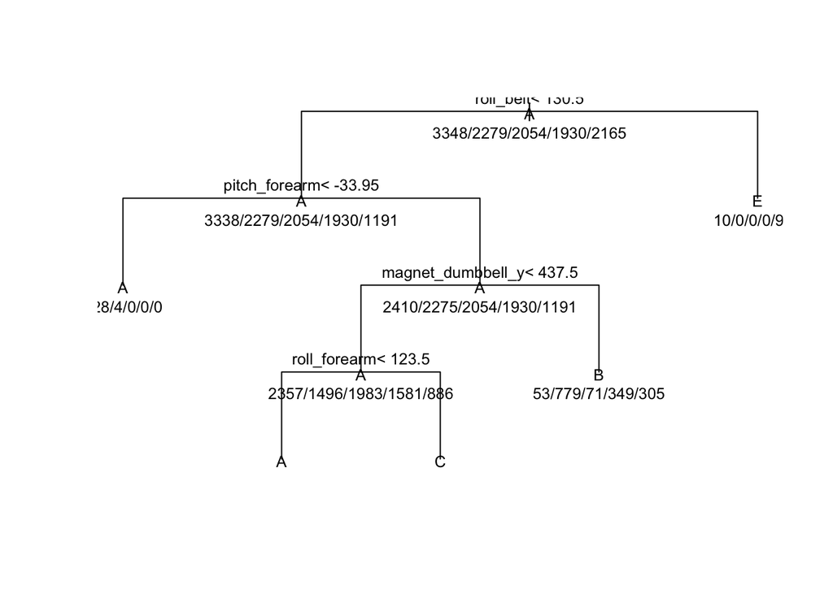

```r
#tree model not very good because does not find D at all, but almost always is accurate with E

#plot tree
plot(model_tree$finalModel, uniform = TRUE)
text(model_tree$finalModel, use.n = TRUE, all = TRUE, cex = 0.8)
```

```r
#try boosting model - this line is commented out because it takes a long time to run so the model was run once then saved.
model_gmb <- train(classe ~ ., method = "gbm", data = newertrain, verbose = FALSE)
```

```r
confusionMatrix(newertrain$classe, predict(model_gmb, newertrain))
```

```
## Confusion Matrix and Statistics
##
##           Reference
## Prediction    A    B    C    D    E
##          A 3310   26    9    2    1
##          B   51 2187   40    1    0
##          C    0   48 1986   18    2
##          D    1    6   44 1873    6
##          E    1   15   13   20 2116
##
## Overall Statistics
##
##                Accuracy : 0.9742
##                  95% CI : (0.9712, 0.977)
##     No Information Rate : 0.2856
##     P-Value [Acc > NIR] : < 2.2e-16
##
##                   Kappa : 0.9673
##  Mcnemar's Test P-Value : 8.721e-10
##
## Statistics by Class:
##
##                      Class: A Class: B Class: C Class: D Class: E
## Sensitivity            0.9842   0.9584   0.9493   0.9786   0.9958
## Specificity            0.9955   0.9903   0.9930   0.9942   0.9949
## Pos Pred Value         0.9886   0.9596   0.9669   0.9705   0.9774
## Neg Pred Value         0.9937   0.9900   0.9891   0.9958   0.9991
## Prevalence             0.2856   0.1938   0.1776   0.1625   0.1805
## Detection Rate         0.2811   0.1857   0.1686   0.1591   0.1797
## Detection Prevalence   0.2843   0.1935   0.1744   0.1639   0.1838
## Balanced Accuracy      0.9899   0.9743   0.9712   0.9864   0.9953
```

```r
confusionMatrix(cv$classe, predict(model_gmb, cv))
```

```
## Confusion Matrix and Statistics
##
##           Reference
## Prediction    A    B    C    D    E
##          A 2191   26   10    3    2
##          B   49 1440   26    2    1
##          C    0   47 1303   13    5
##          D    1    7   45 1221   12
##          E    2   18   15   21 1386
##
## Overall Statistics
##
##                Accuracy : 0.9611
##                  95% CI : (0.9566, 0.9653)
##     No Information Rate : 0.2859
##     P-Value [Acc > NIR] : < 2.2e-16
##
##                   Kappa : 0.9508
##  Mcnemar's Test P-Value : 1.54e-10
##
## Statistics by Class:
##
##                      Class: A Class: B Class: C Class: D Class: E
## Sensitivity            0.9768   0.9363   0.9314   0.9690   0.9858
## Specificity            0.9927   0.9876   0.9899   0.9901   0.9913
## Pos Pred Value         0.9816   0.9486   0.9525   0.9495   0.9612
## Neg Pred Value         0.9907   0.9845   0.9852   0.9941   0.9969
## Prevalence             0.2859   0.1960   0.1783   0.1606   0.1792
## Detection Rate         0.2793   0.1835   0.1661   0.1556   0.1767
## Detection Prevalence   0.2845   0.1935   0.1744   0.1639   0.1838
## Balanced Accuracy      0.9847   0.9620   0.9606   0.9796   0.9885
```